# Data Science Capstone - Milestone Report

Khaled Abdou

December 29, 2015

# Introduction

This report demonstartes applying fundamentals of data science to natural language processing. Data extraction, cleaning and text mining the [HC Copora](http://www.corpora.heliohost.org) will be done. The report is a requirement of the data science capstone project of [Coursera](https://www.coursera.org) and [Swiftkey](http://swiftkey.com/). as frist step to building a prediction application.

# Data

The data has four sets of files German : de_DE English: en_US Finnish: fi_FI Russian : ru_RU Each set has 3 text files with texts from blogs, news and twitter. This analysis we will focus on the english set of files: en_US.blogs.txt, en_US.news.txt, and en_US.twitter.txt

# Data Processing

## Loading Libraries

```r
library(RWekajars)
library(qdapDictionaries)
library(qdapRegex)
library(qdapTools)
library(RColorBrewer)
library(qdap)
library(NLP)
library(tm)
```

```r
library(SnowballC)
library(slam)
library(RWeka)
library(rJava)
library(wordcloud)
library(stringr)
library(DT)
library(stringi)
library(ggplot2)
```

## 1. Loading The Dataset

```r
fileURL <- "http://d396qusza40orc.cloudfront.net/dsscapstone/dataset/Coursera-SwiftKey.zip"
file <- "CourseraSwiftKeyCorporaData.zip"
if (!file.exists(file)){
        download.file(fileURL, destfile=file)
        unlink(fileURL)
}

# Unzip data
if (!dir.exists("./final/en_US")) {
        unzip(file)
}

## Load the en_US datasets

blogs <- readLines("./final/en_US/en_US.blogs.txt",
                   encoding = "UTF-8", skipNul=TRUE)
news <- readLines("./final/en_US/en_US.news.txt",
                  encoding = "UTF-8", skipNul=TRUE)
twitter <- readLines("./final/en_US/en_US.twitter.txt",
                     encoding = "UTF-8", skipNul=TRUE)
```

## 2. Summary Statistics

### 2.1. Summary Statistics On Original Files

```r
blogs_length <- length(blogs)
news_length <- length(news)
twitter_length <- length(twitter)
blogs_file_size <- file.info("./final/en_US/en_US.blogs.txt")$size / 1024.0 / 1024.0
news_file_size <- file.info("./final/en_US/en_US.news.txt")$size / 1024.0 / 1024.0
twitter_file_size <- file.info("./final/en_US/en_US.twitter.txt")$size / 1024.0 / 1024.0
blogs_words <- sum(sapply(gregexpr("\\S+", blogs), length))
news_words <- sum(sapply(gregexpr("\\S+", news), length))
twitter_words <- sum(sapply(gregexpr("\\S+", twitter), length))
```

### 2.2. Generating a random sapmle from all sources

```r
set.seed(4783)
twitter_sample <- twitter[sample(1:twitter_length,10000)]
news_sample <- news[sample(1:news_length,10000)]
blogs_sample <- blogs[sample(1:blogs_length,10000)]
all_sample <- c(twitter_sample,news_sample,blogs_sample)

## Save sample
writeLines(all_sample, "./all_sample.txt")
## Summary Statistics On sample
all_sample_size <- file.info("./all_sample.txt")$size / 1024.0 / 1024.0
all_sample_length <- length(all_sample)
all_sample_words <- sum(sapply(gregexpr("\\S+", all_sample), length))
```

### 2.3. Combine and report Summary Statistics of all sources

```r
summary_of_files <- data.frame(
        fileName = c("Blogs","News","Twitter", "Combined Sample"),
        fileSize = c(round(blogs_file_size, digits = 2),
                     round(news_file_size,digits = 2),
                     round(twitter_file_size, digits = 2),
                     round(all_sample_size, digits = 2)),
        lineCount = c(blogs_length, news_length, twitter_length, all_sample_length),
        wordCount = c(blogs_words, news_words, twitter_words, all_sample_words)
)

colnames(summary_of_files) <- c("File Name", "Size (MB)", "Lines Count", "Words Count")
saveRDS(summary_of_files, file = "./summary_of_files.Rda")
summary_df <- readRDS("./summary_of_files.Rda")
```

## Files Summary Statistics

```r
summary_df
```

```
##         File Name Size (MB) Lines Count Words Count
## 1           Blogs    200.42      899288    37334131
## 2            News    196.28       77259     2643969
## 3         Twitter    159.36     2360148    30373583
## 4 Combined Sample      4.84       30000      885552
```

# Exploratory Analysis

## Build a clean corpus

```r
sample_connection <- file("./all_sample.txt")
sample <- readLines(sample_connection)
close(sample_connection)

## Read in profanity Words
profanity_Words <- read.table("./profanity_word_list.txt", header = FALSE)

## Build the corpus, and specify the sample to be source to be character vectors
clean_sample <- Corpus(VectorSource(sample))
rm(sample)
## Apply tm package
clean_sample <- tm_map(clean_sample,
                      content_transformer(function(x)
                              iconv(x, to="UTF-8", sub="byte")),
                      mc.cores=1)
removeURL <- function(x) gsub("http[[:alnum:]]*", "", x)
## Convert all to lower case
clean_sample <- tm_map(clean_sample, content_transformer(tolower), lazy = TRUE)
## remove punctions
clean_sample <- tm_map(clean_sample, content_transformer(removePunctuation))
## remove numbers
clean_sample <- tm_map(clean_sample, content_transformer(removeNumbers))
## remove URLs
clean_sample <- tm_map(clean_sample, content_transformer(removeURL))
## remove white spaces
clean_sample <- tm_map(clean_sample, stripWhitespace)
## remove stop words
clean_sample <- tm_map(clean_sample, removeWords, stopwords("english"))
## remove profanity words
corpusSample <- tm_map(clean_sample, removeWords, as.character(profanity_Words$V1))
## remove stem  words
clean_sample <- tm_map(clean_sample, stemDocument)

## Save final corpus
saveRDS(clean_sample, file = "./final_corpus.RDS")
final_corpus <- readRDS("./final_corpus.RDS")
final_corpus_df <-data.frame(text=unlist(sapply(final_corpus,`[`, "content")),
                           stringsAsFactors = FALSE)
```

## The N-Gram Tokenization

This is the tokenization function for processing n-grams ngramCount e.g. 1= unigram 2=bigram 3=trigram …etc. Returns top 20

```r
ngramTokenizer <- function(theCorpus, ngramCount) {
        ngramFunction <- NGramTokenizer(theCorpus,
                                        Weka_control(min = ngramCount, max = ngramCount,
                                                     delimiters = " \\r\\n\\t.,;:\"()?!"))
        ngramFunction <- data.frame(table(ngramFunction))
        ngramFunction <- ngramFunction[order(ngramFunction$Freq,
                                             decreasing = TRUE),][1:20,]
        colnames(ngramFunction) <- c("String","Count")
        ngramFunction
}
```

## Apply Tokenization

Tokenize the data into sets of 1, 2 and 3 n-grams.

```r
uni_grams <- ngramTokenizer(final_corpus_df, 1)
saveRDS(uni_grams, file = "./top_uni_grams.RDS")
bi_grams <- ngramTokenizer(final_corpus_df, 2)
saveRDS(bi_grams, file = "./top_bi_grams.RDS")
tri_grams <- ngramTokenizer(final_corpus_df, 3)
saveRDS(tri_grams, file = "./top_tri_grams.RDS")
```

## Top Unigrams

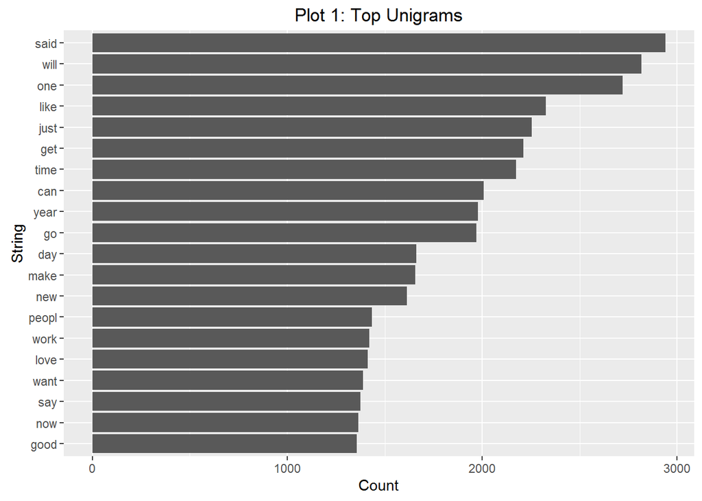

```r
uni_grams <- readRDS("./top_uni_grams.RDS")
uni_grams$String <- factor(uni_grams$String, levels = uni_grams[order(uni_grams$Count), "String"])
p1 <-ggplot(uni_grams, aes(x = String, y = Count)) +
        geom_bar(stat = "identity") + coord_flip()  + theme(legend.position = "none") + ggtitle("Plot 1: Top Unigrams")
plot(p1)
```

## Top Bigrams

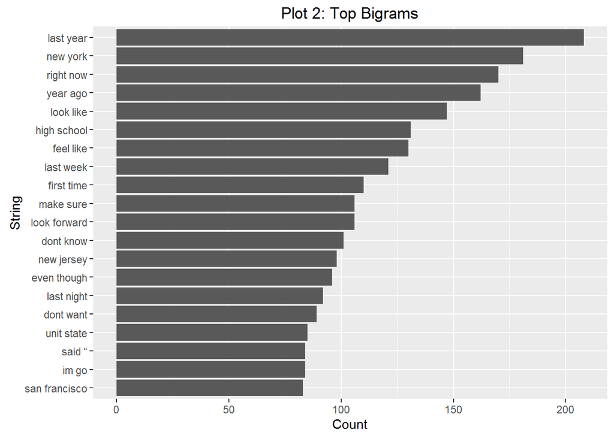

```r
bi_grams <- readRDS("./top_bi_grams.RDS")
bi_grams$String <- factor(bi_grams$String, levels = bi_grams[order(bi_grams$Count), "String"])

p2 <-ggplot(bi_grams, aes(x = String, y = Count)) +
        geom_bar(stat = "identity") + coord_flip()  + theme(legend.position = "none") + ggtitle("Plot 2: Top Bigrams")
plot(p2)
```

## Top Trigrams

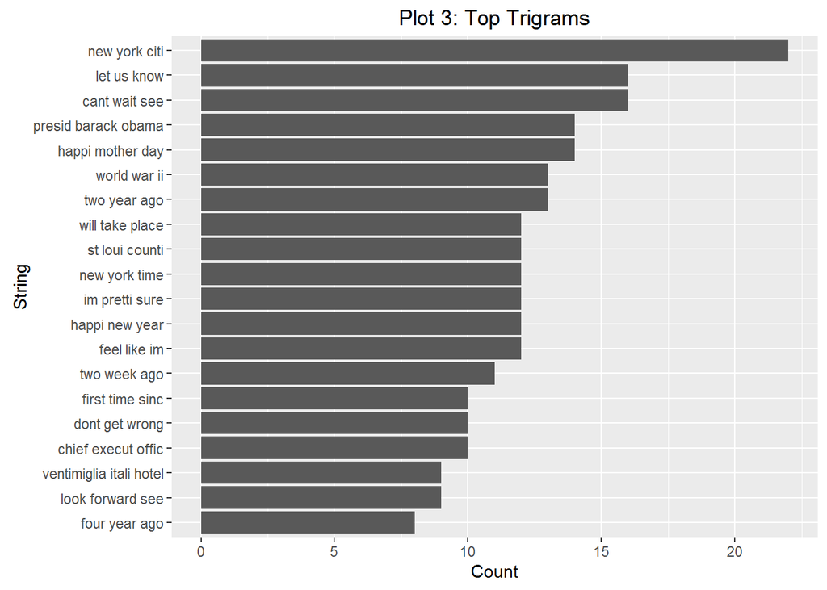

```r
tri_grams <- readRDS("./top_tri_grams.RDS")
tri_grams$String <- factor(tri_grams$String, levels = tri_grams[order(tri_grams$Count), "String"])

p3 <-ggplot(tri_grams, aes(x = String, y = Count)) +
        geom_bar(stat = "identity") + coord_flip()  + theme(legend.position = "none") + ggtitle("Plot 3: Top Trigrams")
plot(p3)
```

# Findings

- Data Sampling is very imporatnat as the size of the origional datasets are very large. Draw back is accuracy of the text mining process will suffer.
- Trigram Chart is showing chopped off words , e.g. *presid barack obama* and *chief execut offi*. Tokinzation needs to be improved.

# Next Steps : The Prediction Application

The next step of the capstone project is to create a prediction application. A shiny application will be created to predict the next word from a user input. Application may have an input text box whose text would be the main input to the algorithm. Size of the input to the algorithm maybe limited to up to the last 3 words of the phrase.

# Code

Code to generate this report is at [repository](https://github.com/abdoukm/coursera_capstone/tree/master/MilestoneReport).